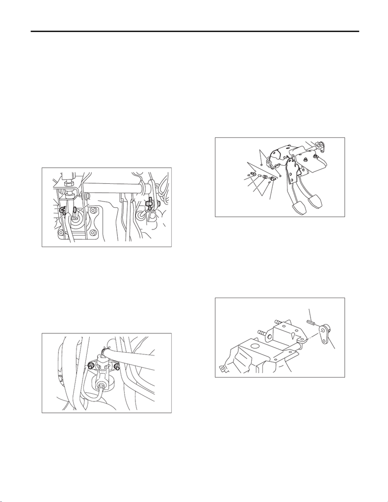

CL-31

Clutch Pedal

CLUTCH SYSTEM

10.Clutch Pedal

A: REMOVAL

1) Disconnect the ground cable from battery. <Ref.

to NT-5, BATTERY, NOTE, Note.>

NOTE:

For models other than STI model, disconnect the

ground terminal from battery sensor.

2) Remove the steering column. <Ref. to PS-25,

REMOVAL, Steering Column.>

3) Disconnect the connector from the stop light

switch and clutch switch.

4) Remove the snap pins from clevis pins which se-

cure the lever to the push rod and operating rod.

5) Pull out the clevis pins which secures the lever to

the push rod and operating rod.

6) Remove the intercooler.

<Ref. to IN(STI)-13, REMOVAL, Intercooler.>

<Ref. to IN(w/o STI)-38, REMOVAL, Intercooler.>

7) Remove the nut which secures the clutch master

cylinder.

8) Remove the bolts and nuts which secure the

brake pedal and clutch pedal, and remove the ped-

al assembly.

B: INSTALLATION

1) Install in the reverse order of removal.

CAUTION:

Always use a new clevis pin.

2) Adjust the clutch pedal after installation. <Ref. to

CL-33, ADJUSTMENT, Clutch Pedal.>

3) Adjust the clutch start switch. <Ref. to CL-37,

ADJUSTMENT, Clutch Switch.>

C: DISASSEMBLY

1) Remove the clutch switches.

2) Remove the clip, assist spring, rod and bushing.

3) Remove the spring pin and lever.

(A) Operating rod

(B) Push rod

(C) Snap pin

(D) Clevis pin

CL-00090

(B)

(C)

(D)

(D)

(C)

(A)

CL-01011

(A) Clip

(B) Assist spring

(C) Assist rod A

(D) Assist rod B

(E) Assist bushing

(F) Clutch clevis pin

(G) Bushing

(A) Spring pin

(B) Lever

CL-00692

(A)

(B)

(C)

(D)

(G)

(E)

(F)

CL-00095

(A)

(B)

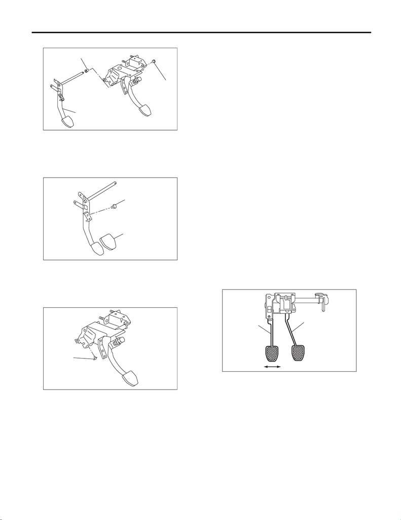

CL-32

Clutch Pedal

CLUTCH SYSTEM

4) Remove the clutch pedal and bushings.

5) Remove the stopper and clutch pedal pad from

the clutch pedal.

6) Remove the stopper from the clutch pedal brack-

et.

D: ASSEMBLY

1) Attach the stopper and clutch pedal pad to the

clutch pedal.

2) Install the clutch switch to the pedal bracket.

3) Clean the pedal bushing holes of the clutch ped-

al and the brake pedal, apply grease, and install the

pedal bushings.

4) Install the clutch pedal, brake pedal and lever to

the pedal bracket, and fix with a spring pin.

5) Install the assist rod A, assist rod B, assist bush-

ing and assist spring to the clutch pedal and pedal

bracket.

E: INSPECTION

1) Check the free play of the clutch pedal.

NOTE:

Check by pressing the pedal.

Clutch pedal free play:

5 — 11 mm (0.2 — 0.43 in)

2) Move the clutch pedal pads in the lateral direc-

tion with a force of approximately 10 N (1 kgf, 2 lbf)

to check that the clutch pedal deflection is within

the service limit.

CAUTION:

If the play exceeds the service limit, replace the

bushing with a new part.

Deflection of the clutch pedal:

Service limit

4.0 mm (0.157 in) or less

(A) Clutch pedal

(B) Bushing

(A) Stopper

(B) Clutch pedal pad

(A) Stopper

CL-00602

(B)

(A)

(B)

CL-00670

(A)

(B)

CL-00603

(A)

(A) Clutch pedal

(B) Brake pedal

CL-00098

(A)

(B)

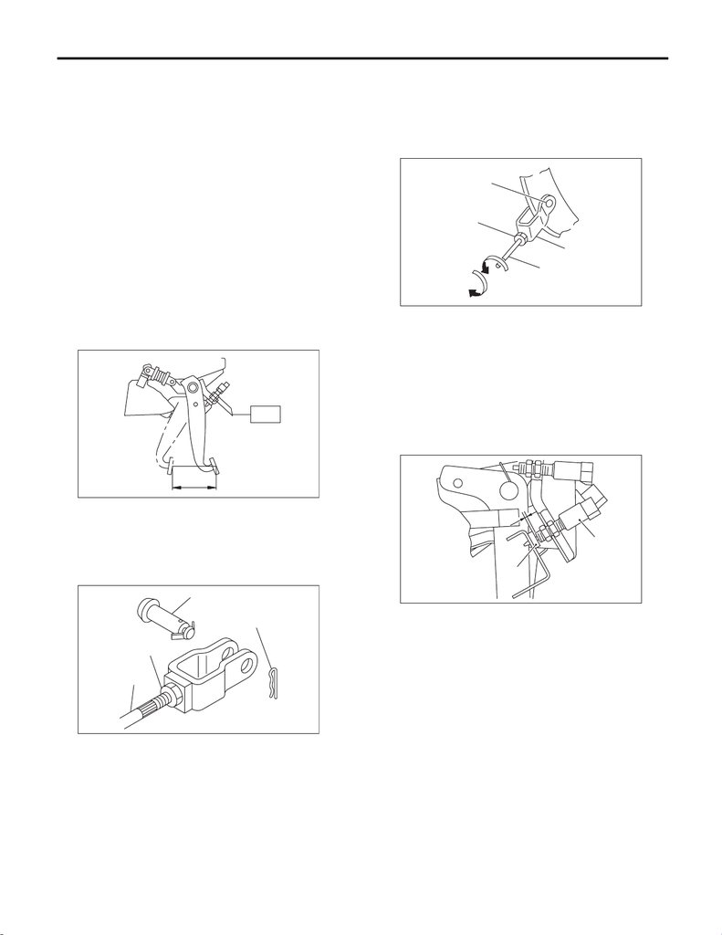

CL-33

Clutch Pedal

CLUTCH SYSTEM

F: ADJUSTMENT

1) Turn the lock nut until the full stroke of clutch

pedal becomes within the specification.

CAUTION:

When adjusting the full stroke of clutch pedal,

do not turn the clutch switch.

NOTE:

If the lock nut cannot adjust the full stroke of clutch

pedal to the specified value, adjust it by turning the

master cylinder push rod.

Clutch pedal full stroke A:

STI model

130 — 135 mm (5.12 — 5.31 in)

Except for STI model

135 — 140 mm (5.31 — 5.51 in)

Tightening torque (clutch switch lock nut):

T: 8 N·m (0.8 kgf-m, 5.9 ft-lb)

2) If the full stroke is not within the specified value,

loosen the clutch switch lock nut to adjust.

Tightening torque:

8 N·m (0.8 kgf-m, 5.9 ft-lb)

3) Loosen the push rod lock nuts.

4) Rotate the push rod to adjust.

(1) Make sure that the clutch pedal contacts the

clutch switch side when the pedal is released.

(2) Make sure that the clutch pedal contacts the

clutch pedal bracket stopper when the clutch

pedal is at the maximum stroke position.

5) Turn the push rod to shorten until a clearance is

gained on the clutch switch side.

(A) Clevis pin

(B) Snap pin

(C) Push rod

(D) Push rod lock nut

CL-00225

T

A

CL-00042

(A)

(B)

(C)

(D)

(A) Clevis hole

(B) Push rod lock nut

(C) In the shorter direction

(D) In the longer direction

(E) Push rod

(F) Clevis

(A) Clutch switch

(B) Stopper

CL-00080

(B)

(A)

(C)

(D)

(E)

(F)

CL-00605

(A)

(B)

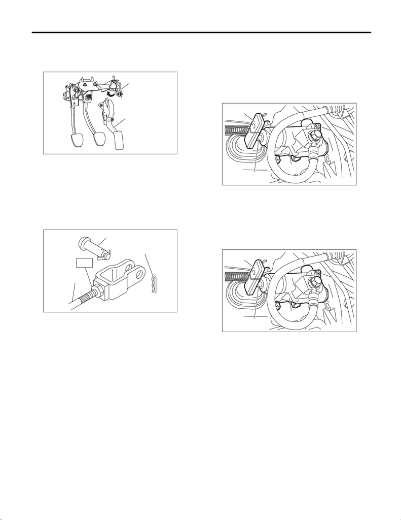

CL-34

Clutch Pedal

CLUTCH SYSTEM

6) Turn the push rod to lengthen until clutch pedal

contacts the clutch switch.

7) Turn further in the direction that will shorten the

push rod (arrow direction shown in figure) by 270°.

8) Check that the clevis pin moves smoothly by

moving it in the left and right directions.

9) Tighten the push rod lock nut.

Tightening torque (push rod lock nut):

T: 10 N·m (1.0 kgf-m, 7.4 ft-lb)

10) Depress and release the clutch pedal two or

three times to ensure that the clutch pedal and re-

lease lever operate smoothly. If the clutch pedal

and release lever do not operate smoothly, bleed

air from the clutch hydraulic system. <Ref. to CL-

29, Clutch Fluid Air Bleeding.>

11) Measure the clutch pedal full stroke length

again to ensure that it is within specifications. If it is

not within specifications, repeat adjustment proce-

dures again from the beginning.

Clutch pedal full stroke:

STI model

130 — 135 mm (5.12 — 5.31 in)

Except for STI model

135 — 140 mm (5.31 — 5.51 in)

12) Push the release lever until the operating cylin-

der push rod retracts. Make sure that the clutch flu-

id level in the reservoir tank increases. If the clutch

fluid level increases, the hydraulic clutch is properly

adjusted. If the fluid level does not increase or the

der.>

13) Push the release lever until the operating cylin-

der push rod retracts. Check that the clutch fluid

level in the reservoir tank increases.

14) If the clutch fluid level increases, hydraulic

clutch play is correct.

15) If the clutch fluid level does not increase or

push rod does not retract, readjust the clutch pedal.

16) Check the fluid level using the scale on the out-

side of the reservoir tank. <Ref. to CL-28, INSPEC-

TION, Clutch Fluid.>

(A) Accelerator pedal

(B) Clevis

(A) Clevis pin

(B) Snap pin

(C) Push rod

CL-00600

(B)

(A)

CL-00226

(A)

(B)

(C)

T

(A) Push rod

(B) Release lever

(C) Operating cylinder

(A) Push rod

(B) Release lever

(C) Operating cylinder

CL-00663

(A)

(B)

(C)

CL-00663

(A)

(B)

(C)